# Welcome to Code-along Workship

### October 13 - Session - No 4

### Topic - Clustering

# Instructor - Swetha Tanamala

- Completed B-Tech and M-Tech from IIT Madras
  - Machine Learning Electives and Projects from the 4th semester
  - Year Long Project on Pattern Recognition
- Joined [Qure](http://qure.ai/) as Data Scientist
  - Deep Learning Algorithms
  - Natural Language Processing
  - AWS for data storing
  - [Blog](https://swethatanamala.github.io/)

# Agenda

- Introduction to Clustering
- Various Clustering methods
- k-means clustering
- Clustering in Python

# Types of Learning methods

- Supervised Learning methods
- Unsupervised Learning methods
- Semi-Supervised Learning methods
- Reinforcement Learning methods

# Supervised Learning Methods

[figure not shown]

# Algorithms for Supervised learning

- Support Vector Machines (SVM)
- Linear Regression
- Logistic Regression
- Linear Discriminant Analysis (LDA)
- Neural Networks

# Unsupervised Learning Methods

- Unsupervised learning is a branch of machine learning that learns from the data that has not been labeled, classified or categorized

[figure not shown]

# Aim is to find the structure and relationship within this data

# What can be the problems?

- Clustering the data
- Dimensionality Reduction
- Predicting Probability Density function(PDF)

# Cluster Analysis

> Cluster analysis or clustering is the task of grouping a set of objects in such a way that objects in the same group (called a cluster) are more similar (in some sense or another) to each other than to those in other groups (clusters).

# Clustering - Let's keep it simple

- Organise the given input data into the given number of clusters (say k)
- Objective
  - High intra Cluster similarity
  - Low inter Cluster similarity

# How do we Calculate similarity?

- Simlarity of cluster analysis depends on what?

# Answer

- Achieved by
  - what constitutes a cluster
  - how to efficiently find them.
- Therefore, Cluster analysis itself is not one specific algorithm, but the general task to be solved

# Applications of clustering - Unsupervised Machine learning

Clustering is an extremely useful technique in **both supervised and unsupervised machine learning**

- Clustering is one of the most popular techniques for spotting the underlying pattern in a dataset
- Some of the use cases are:
  - It started with pulse code modulation in Bell Labs in 1957 - Then it is called Floyd's algorithm
  - Clustering genes
  - Market Segmentation
  - Clustering web-pages, example: news.google.com

# Applications of clustering - Supervised Machine learning

#### Exploratory Data Analysis

- Which observations are nearer to each-other
  - Algorithm: k-nearset neighbors algorithm
- Example

[figure not shown]

# Let's understand few models

- Now we understood: Cluster analysis itself is not one specific algorithm, but the **general task** to be solved.
- Models
  - Connectivity models: Hierarchical clustering

# Hierarchial Clustering

**Hierarchical clustering**, in which,

- Clusters can be **visualized using a dendrogram** (aka tree diagram)
- Possible to view partitions at different levels of granularities (i.e., can refine/coarsen clusters) using different K

[figure not shown]

# Hierarchial Clustering

There are two major ways in which hierarchical clustering can be carried out:

1. Agglomerative or Bottom-Up Clustering
2. Divisive or Top-Down Clustering

# Agglomerative Clustering

## Key operation

# Key questions

1. How do you represent a cluster of more than one point?
2. How do you determine the **nearness** of clusters?
3. When to stop combining clusters?

Understand the answers to the above questions by working on a example

# Euclidean Space

> Average two points and consider average is also an point (artificial)
1. Ans: Centroid to present a cluster, here centroid is a average of all points in cluster
2. Ans: Measure cluster distances by distances of centroids

# Non Euclidean Space

> Doesn't use centroid to represent the cluster
1. Ans: Clustroid - This is point itself which is closest to other points
2. Ans: Treat clustroid as if it were centroid when compiling intercluster distances

# When to stop clustering?

1. If k is already given, then stop when we have k clusters
2. Stop when next merge would create a cluster with low cohesion
   - Cohesion: goodness of cluster
   - If diameter is less than certain threshold
   - If radius is less than certain threshold
   - If density is less than certain threshold

# Complexity

1. Naive implementation - $O(N^3)$
2. Careful implementation using priority queue - $O(N^2logN)$ at the cost of memory overhead

Therefore doesn't fit to **big datasets**

# K-means Clustering

k-means clustering aims to partition **n observations** into **k clusters** in which each observation belongs to the cluster with the nearest mean, serving as a prototype of the cluster.

Clusters in "k-means clustering" follow these two underlying rules

- The "cluster center" is the arithmetic mean of all the points belonging to the cluster.
- Each point is closer to its own cluster center than to other cluster centers.

[figure not shown]

# Let's look at math

The K-means objective function for k-means as follows:

- Let µ1, . . . , µK be the K cluster centroids (means)
- Let $r_{nk}$ ∈ {0, 1} be indicator denoting whether point $x_n$ belongs to cluster k

K-means objective minimizes the total distortion (sum of distances of points from their cluster centers)

$$J(µ,r) = \sum_{n=1}^{N}\sum_{k=1}^{K}r_{nk}||X_n − µ_k ||^2$$

## K-means: A bit of math

The exact optimization of the K-means objective is **NP-hard**, which means that actually solving the problem is computationally very expensive, however, given a solution, checking whether it is correct or not is relatively easy!

This means that actually solving the problem and coming up with cluster centroids is computationally very expensive. However, given a set of cluster centroids, checking if they are good approximations is computationally cheap. Therefore, the **K-means algorithm is performed using a heuristic** that helps us converge to a solution faster. Let's see how that works.

# K-means: Algorithmic approach

k-means is a particularly simple and easy-to-understand application of an iterative algorithm known as **Expectation–Maximization**, and we will walk through it briefly here.

The expectation–maximization approach here consists of the following procedure:

1. Guess some cluster centers
2. Repeat until converged
   - E-Step: assign points to the nearest cluster center
   - M-Step: set the cluster centers to the mean

# More on Expectation–Maximization

- Here the "E-step" or "Expectation step" is so-named because it involves updating our expectation of which cluster each point belongs to.
- The "M-step" or "Maximization step" is so-named because it involves maximizing some fitness function that defines the location of the cluster centers — in this case, that maximization is accomplished by taking a simple mean of the data in each cluster.

This algorithm can be summarized as follows: **Under typical circumstances, each repetition of the E-step and M-step will always result in a better estimate of the cluster characteristics.*

Great! Now, let's see how this heuristic is performed.

# Populating clusters

- **Step 1**: Start by making a guess on where the central points of each cluster are. Let’s call these pseudo-centers, since we do not yet know if they are actually at the center of their clusters.
- **Step 2**: Assign each data point to the nearest pseudo-center. By doing so, we have just formed clusters, with each cluster comprising all data points associated with its pseudo-center.
- **Step 3**: Update the location of each cluster’s pseudo-center, such that it is now indeed in the center of all its members.
- **Step 4**: Repeat the steps of re-assigning cluster members (Step 2) and re-locating cluster centers (Step 3), until there are no more changes to cluster membership.

[figure not shown]

Let's understand the k-means clustering algorithm using following **examples**

# **gif 1: 2 Clusters Example**

[figure not shown]

# **gif 2: Multiple Clusters Example**

[figure not shown]

In the next few slides, we will check why k-means is so popular among all clustering algorithms

# Popularity of k-means

- Fast
- Easy to understand
- Available everywhere

# Popularity of k-means

To demonstrate the popularity of k-means, here are some variants. And no, we are not going to cover them!

- K-Means
- K-Means++ (only changes how to initialize centroids)
- Online K-Means
- Spherical K-Means
- K-Medoids
- Kernel K-Means
- K-Modes
- Bisecting K-Means
- Fuzzy C-Means

Time to make our hands dirty!! Will start now programmatic approach

# K-means clustering in `sklearn`

Many clustering algorithms are available in Scikit-Learn and elsewhere, but perhaps the simplest to understand is k-means clustering, which is implemented in **`sklearn.cluster.KMeans`**

# Iris data for understanding k-means clustering

[figure not shown]

# The dataset contains a set of 150 records under five attributes

- petal length
- petal width
- sepal length
- sepal width
- species as class name

```python
import pandas as pd, numpy as np
from sklearn.cluster import KMeans
from sklearn.datasets import load_iris
```

```python
iris = load_iris()
```

```python
X = iris.data
y = iris.target
```

```python
X[1]
```

```
array([4.9, 3. , 1.4, 0.2])
```

```python
#Groundtruths
np.unique(y)
```

```
array([0, 1, 2])
```

# About k-means in scikit learn

### Parameters

- **n_clusters** : integer
- **init** - can be ‘k-means++’, ‘random’ or an ndarray
- **n_init** - Number of time the k-means algorithm will be run with different centroid seeds
- **max_iter** - Maximum number of iterations of the k-means algorithm for a single run

### Ouput in attributes

```python
km = KMeans(init="random", n_clusters=5)
km.fit(X)
```

```
KMeans(algorithm='auto', copy_x=True, init='random', max_iter=300,
    n_clusters=5, n_init=10, n_jobs=None, precompute_distances='auto',
    random_state=None, tol=0.0001, verbose=0)
```

```python
km.labels_
```

```
array([0, 0, 0, 0, 0, 0, 0, 0, 0, 0, 0, 0, 0, 0, 0, 0, 0, 0, 0, 0, 0, 0,
       0, 0, 0, 0, 0, 0, 0, 0, 0, 0, 0, 0, 0, 0, 0, 0, 0, 0, 0, 0, 0, 0,
       0, 0, 0, 0, 0, 0, 1, 1, 1, 4, 1, 1, 1, 4, 1, 4, 4, 1, 4, 1, 4, 1,
       1, 4, 1, 4, 1, 4, 1, 1, 1, 1, 1, 1, 1, 4, 4, 4, 4, 1, 4, 1, 1, 1,
       4, 4, 4, 1, 4, 4, 4, 4, 4, 1, 4, 4, 3, 1, 2, 3, 3, 2, 4, 2, 3, 2,
       3, 3, 3, 1, 3, 3, 3, 2, 2, 1, 3, 1, 2, 1, 3, 2, 1, 1, 3, 2, 2, 2,
       3, 1, 1, 2, 3, 3, 1, 3, 3, 3, 1, 3, 3, 3, 1, 3, 3, 1], dtype=int32)
```

```python
km.cluster_centers_
```

```
array([[5.006     , 3.428     , 1.462     , 0.246     ],
       [6.20769231, 2.85384615, 4.74615385, 1.56410256],
       [7.475     , 3.125     , 6.3       , 2.05      ],
       [6.52916667, 3.05833333, 5.50833333, 2.1625    ],
       [5.508     , 2.6       , 3.908     , 1.204     ]])
```

```python
km.predict(X[1, np.newaxis])
```

[output not shown]

# Synthetic data for testing clustering algorithms

We'll create (and plot) synthetic datasets to understand k-means clustering better.

```python
import matplotlib.pyplot as plt
import seaborn as sns
import sklearn.cluster as cluster
import time

%matplotlib inline
sns.set_context('poster')
sns.set_color_codes()
plot_kwds = {'alpha' : 0.25, 's' : 80, 'linewidths':0}
```

```python
# generate two clusters: a with 100 points, b with 50:
np.random.seed(9)  # for repeatability of this tutorial
a = np.random.multivariate_normal([10, 0], [[3, 1], [1, 4]], size=[100,])
b = np.random.multivariate_normal([0, 20], [[3, 1], [1, 4]], size=[50,])
X = np.concatenate((a, b),)
print(X.shape)  # 150 samples with 2 dimensions
```

```
(150, 2)
```

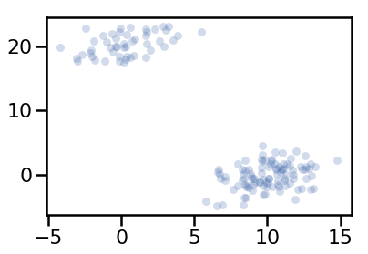

```python
plt.scatter(X[:,0], X[:,1], c='b', **plot_kwds)
frame = plt.gca()
frame.axes.get_xaxis().set_visible(True)
frame.axes.get_yaxis().set_visible(True)
plt.show()
```

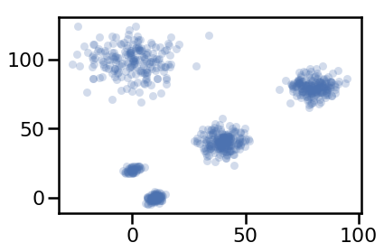

```python
c = np.random.multivariate_normal([40, 40], [[20, 1], [1, 30]], size=[200,])
d = np.random.multivariate_normal([80, 80], [[30, 1], [1, 30]], size=[200,])
e = np.random.multivariate_normal([0, 100], [[100, 1], [1, 100]], size=[200,])
X2 = np.concatenate((X, c, d, e),)
plt.scatter(X2[:,0], X2[:,1],  c='b', **plot_kwds)
frame = plt.gca()
frame.axes.get_xaxis().set_visible(True)
frame.axes.get_yaxis().set_visible(True)
plt.show()
```

```python
def plot_clusters(data, algorithm, args, kwds):
    start_time = time.time()
    labels = algorithm(*args, **kwds).fit_predict(data)
    end_time = time.time()
    palette = sns.color_palette('deep', np.unique(labels).max() + 1)
    colors = [palette[x] if x >= 0 else (0.0, 0.0, 0.0) for x in labels]
    plt.scatter(data.T[0], data.T[1], c=colors, **plot_kwds)
    frame = plt.gca()
    frame.axes.get_xaxis().set_visible(False)
    frame.axes.get_yaxis().set_visible(False)
    plt.title('Clusters found by {}'.format(str(algorithm.__name__)), fontsize=24)
    plt.text(5, 10, 'Clustering took {:.2f} s'.format(end_time - start_time), fontsize=14)
```

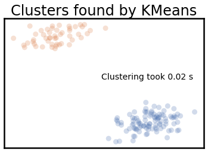

```python
plot_clusters(X, cluster.KMeans, (),{'n_clusters':2})
```

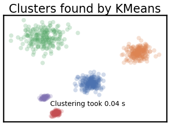

```python
plot_clusters(X2, cluster.KMeans, (), {'n_clusters':5})
```

# Shortcomings of k-means

**The globally optimal result may not be achieved**

**Way out**

- For this reason, it is common for the algorithm to be run for multiple starting guesses, as indeed Scikit-Learn does by default (set by the n_init parameter, which defaults to 10).
- Use better initialization strategies like k-means++

# Shortcomings of k-means

**You need to specify exactly how many clusters you expect**

- If you know a lot about your data then that is something you might expect to know
- If, on the other hand, you are simply exploring a new dataset, then 'number of clusters' is a hard parameter to have any good intuition for

**Way out**

The usually proposed solution is to run K-Means for many different 'number of clusters' values and score each clustering with some 'cluster goodness' measure (usually a variation on intra-cluster vs inter-cluster distances) and attempt to find an 'elbow'

```python
# k means determine k
distortions = []
K = range(1,8)
for k in K:
    kmeanModel = KMeans(n_clusters=k)
    kmeanModel.fit(X)
    distortions.append(kmeanModel.inertia_)
```

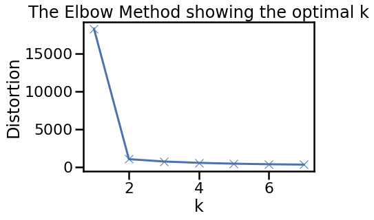

```python
# Plot the elbow
plt.plot(K, distortions, 'bx-')
plt.xlabel('k')
plt.ylabel('Distortion')
plt.title('The Elbow Method showing the optimal k')
plt.show()
```

```python
# k means determine k
distortions = []
K = range(1,12)
for k in K:
    kmeanModel = KMeans(n_clusters=k)
    kmeanModel.fit(X2)
    distortions.append(kmeanModel.inertia_)
```

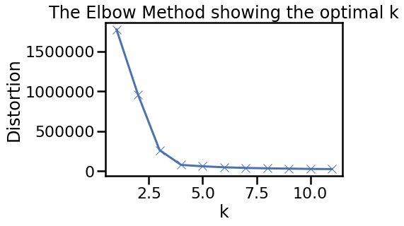

```python
# Plot the elbow
plt.plot(K, distortions, 'bx-')
plt.xlabel('k')
plt.ylabel('Distortion')
plt.title('The Elbow Method showing the optimal k')
plt.show()
```

# Shortcomings of k-means

**k-means is limited to linear cluster boundaries**

- The fundamental model assumptions of k-means (points will be closer to their own cluster center than to others) means that the algorithm will often be ineffective if the clusters have complicated geometries.
- In particular, the boundaries between k-means clusters will always be linear, which means that it will fail for more complicated boundaries:

```python
from sklearn.datasets import make_moons
X3, y3 = make_moons(200, noise=.05, random_state=0)
```

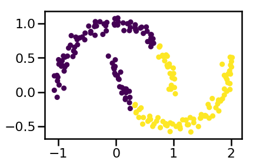

```python
labels = KMeans(2, random_state=0).fit_predict(X3)
plt.scatter(X3[:, 0], X3[:, 1], c=labels, s=50, cmap='viridis');
```

### Way out

One way to overcome this is through kernelized k-means, which is implemented in `Scikit-Learn` within the `SpectralClustering` estimator. It uses the graph of nearest neighbors to compute a higher-dimensional representation of the data, and then assigns labels using a k-means algorithm

We will not be covering these topics. However, here is [sklearn's page on various clustering techniques](http://scikit-learn.org/stable/modules/clustering.html). It is good starting point.

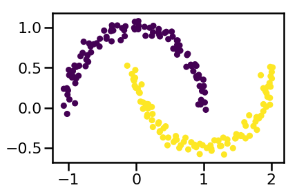

```python
from sklearn.cluster import SpectralClustering
model = SpectralClustering(n_clusters=2, affinity='nearest_neighbors', assign_labels='kmeans')
labels = model.fit_predict(X3)
plt.scatter(X3[:, 0], X3[:, 1], c=labels, s=50, cmap='viridis');
```

# Shortcomings of k-means

**It is a partitioning algorithm**

- It partitions your dataset into as many (assumed to be globular) chunks as you ask for by attempting to minimize intra-partition distances
- Can not accommodate clusters of different shapes (other than the one determined by its distance metric)

# # Shortcomings of k-means

1. Inability to identify non-linear boundaries

[figure not shown]

# Summary: Shortcomings of k-means

[figure not shown]

# Shortcomings of k-means

**k-means can be slow for large numbers of samples**

- Because each iteration of k-means must access every point in the dataset, the algorithm can be relatively slow as the number of samples grows.
- The complexity for each run is $O(kN)$

**Way out**

- One way to overcome this problem is through relaxing requirement to use all data at each iteration can be relaxed.
- For example, we might just use a subset of the data to update the cluster centers at each step.
- This is the idea behind **batch-based k-means algorithms**, one form of which is implemented in **`sklearn.cluster.MiniBatchKMeans`**.
- Can also use BFR algorithm to run a single pass over the entire data

# Thank you

[output not shown]